# Aggregation by Polygon

Mazama Science

2020-04-06

## Overview

This vignette demonstrates how to intersect spatial and gridded data, aggregating values by spatial polygon. This is useful when creating summary statistics at the state or county level. These statistics can then be presenteted as a table or as a [chloropleth map](https://en.wikipedia.org/wiki/Choropleth_map).

This technique uses *sp* style spatial objects and is for those already familiar with the *MazamaSpatialUtils* package.

### Spatial data setup

The *MazamaSpatialUtils* package is already a requirement for *AirFireModeling* and is therefore already installed. We will use datasets named `USCensusStates` and `USCensusCounties`. Each of these is an *sp* package `SpatialPolygonsDataFrame` (SPDF). These are “S4” objects with per-polygon data stored in the `@data` slot.

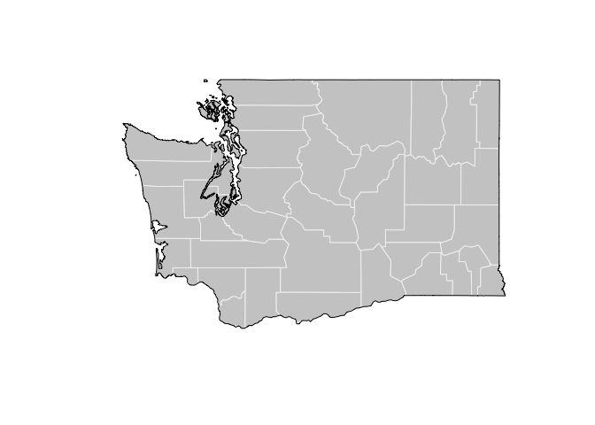

```r
library("MazamaSpatialUtils")
setSpatialDataDir("~/Data/Spatial")

loadSpatialData("USCensusStates")
loadSpatialData("USCensusCounties")

WA <- subset(USCensusStates, stateCode == "WA")
WA_counties <- subset(USCensusCounties, stateCode == "WA")

plot(WA_counties, col = "gray80", border = "gray95")
plot(WA, add = TRUE)
```

```r
# If either dataset is missing you can install them with
# installSpatialData()
#
# Then look to see what was installed
# installedSpatialData()
```

Data are accessbile from the `@data` slot which can be accessed explicitly or by reference to the SPDF.

```r
# Column names
names(WA) # Explicitly: names(WA_counties@data)
```

```
##  [1] "FIPS"        "GNISCode"    "AFFGeoID"    "GeoID"       "stateCode"
##  [6] "stateName"   "LSAD"        "areaLand"    "areaWater"   "countryCode"
## [11] "polygonID"
```

```r
# County names
WA_counties$name
```

```
##  [1] "Columbia"     "Wahkiakum"    "Mason"        "Garfield"     "Clark"
##  [6] "Adams"        "Island"       "Pierce"       "Skamania"     "Chelan"
## [11] "Thurston"     "Ferry"        "Franklin"     "Klickitat"    "Clallam"
## [16] "Jefferson"    "Lincoln"      "Snohomish"    "Okanogan"     "Skagit"
## [21] "Lewis"        "Whatcom"      "San Juan"     "King"         "Pend Oreille"
## [26] "Stevens"      "Kittitas"     "Kitsap"       "Asotin"       "Spokane"
## [31] "Douglas"      "Walla Walla"  "Yakima"       "Grant"        "Benton"
## [36] "Whitman"      "Cowlitz"      "Grays Harbor" "Pacific"
```

### Load raster data

We will load data from a bluesky model and create a subset for Washington state.

Pay attention to the different types of “raster” operations. Functions named `raster_~()` all come from the *AirFireModeling* package while we will use explicit namespacing, *e.g.* `raster::crop()`, for functions that come from the *raster* package.

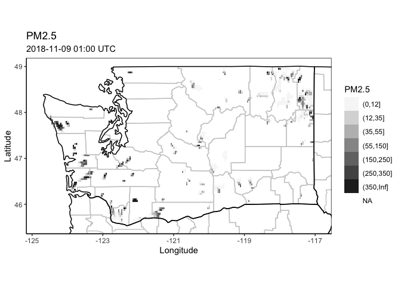

```r
library(AirFireModeling) # For base package support
setModelDataDir("~/Data/BlueSky")

WA_PNW_4km <-
  bluesky_load(model = 'PNW-4km', modelRun = 2018110900) %>%
  raster::crop(WA) %>%
  raster_subsetByPolygon(WA)

# A quick ggplot map from the AirFireModeling package
raster_ggmap(WA_PNW_4km)
```

### Summarizing data

*NOTE: Summarizing by polygon can take a while.*

```r
# Summarize raster by polygon
WA_counties_improved <-
  raster::extract(
    WA_PNW_4km,
    WA_counties,
    fun = function(x, ...) { mean(x, ...) },
    na.rm = TRUE,
    sp = TRUE
  )

# Additional columns or raster data have now been added to the SPDF
names(WA_counties_improved)
```

```
##  [1] "name"        "areaLand"    "areaWater"   "countryCode" "stateCode"
##  [6] "countyName"  "countyFIPS"  "COUNTYNS"    "polygonID"   "X1541725200"
## [11] "X1541728800" "X1541732400" "X1541736000" "X1541739600" "X1541743200"
## [16] "X1541746800" "X1541750400" "X1541754000" "X1541757600" "X1541761200"
## [21] "X1541764800" "X1541768400" "X1541772000" "X1541775600" "X1541779200"
## [26] "X1541782800" "X1541786400" "X1541790000" "X1541793600" "X1541797200"
## [31] "X1541800800" "X1541804400" "X1541808000" "X1541811600" "X1541815200"
## [36] "X1541818800" "X1541822400" "X1541826000" "X1541829600" "X1541833200"
## [41] "X1541836800" "X1541840400" "X1541844000" "X1541847600" "X1541851200"
## [46] "X1541854800" "X1541858400" "X1541862000" "X1541865600" "X1541869200"
## [51] "X1541872800" "X1541876400" "X1541880000" "X1541883600" "X1541887200"
## [56] "X1541890800" "X1541894400" "X1541898000" "X1541901600" "X1541905200"
## [61] "X1541908800" "X1541912400" "X1541916000" "X1541919600" "X1541923200"
## [66] "X1541926800" "X1541930400" "X1541934000" "X1541937600" "X1541941200"
## [71] "X1541944800" "X1541948400" "X1541952000" "X1541955600" "X1541959200"
## [76] "X1541962800" "X1541966400" "X1541970000" "X1541973600" "X1541977200"
```

The columns of the form `X1541725200` are all raster layers whose names encode the UTC time. These can be extracted with:

```r
layerNames <-
  names(WA_counties_improved) %>%
  stringr::str_subset("X[0-9]{10}")

layerTimes <- raster_createLayerNameTimes(layerNames)

print(layerTimes)
```

```
##  [1] "2018-11-09 01:00:00 UTC" "2018-11-09 02:00:00 UTC"
##  [3] "2018-11-09 03:00:00 UTC" "2018-11-09 04:00:00 UTC"
##  [5] "2018-11-09 05:00:00 UTC" "2018-11-09 06:00:00 UTC"
##  [7] "2018-11-09 07:00:00 UTC" "2018-11-09 08:00:00 UTC"
##  [9] "2018-11-09 09:00:00 UTC" "2018-11-09 10:00:00 UTC"
## [11] "2018-11-09 11:00:00 UTC" "2018-11-09 12:00:00 UTC"
## [13] "2018-11-09 13:00:00 UTC" "2018-11-09 14:00:00 UTC"
## [15] "2018-11-09 15:00:00 UTC" "2018-11-09 16:00:00 UTC"
## [17] "2018-11-09 17:00:00 UTC" "2018-11-09 18:00:00 UTC"
## [19] "2018-11-09 19:00:00 UTC" "2018-11-09 20:00:00 UTC"
## [21] "2018-11-09 21:00:00 UTC" "2018-11-09 22:00:00 UTC"
## [23] "2018-11-09 23:00:00 UTC" "2018-11-10 00:00:00 UTC"
## [25] "2018-11-10 01:00:00 UTC" "2018-11-10 02:00:00 UTC"
## [27] "2018-11-10 03:00:00 UTC" "2018-11-10 04:00:00 UTC"
## [29] "2018-11-10 05:00:00 UTC" "2018-11-10 06:00:00 UTC"
```

[output cut: 21 more lines]

### Summary dataframe

Creating a summary dataframe is just a matter of rearranging things.

```r
# Extract summary data and transpose
timeByCountyMatrix <-
  WA_counties_improved@data[, layerNames] %>%
  t()

# Create dataframe with 'datetime' column and county names
timeByCountyDF <- data.frame(timeByCountyMatrix)
names(timeByCountyDF) <- WA_counties_improved$name
timeByCountyDF <- dplyr::bind_cols(datetime = layerTimes, timeByCountyDF)

# Look at a portion of the new dataframe
knitr::kable(
  timeByCountyDF[1:10,1:6],
  format = "markdown",
  digits = 0
)
```

| datetime | Columbia | Wahkiakum | Mason | Garfield | Clark |
| --- | --- | --- | --- | --- | --- |
| 2018-11-09 01:00:00 | 0 | 0 | 0 | 0 | 14 |
| 2018-11-09 02:00:00 | 0 | 4 | 0 | 0 | 34 |
| 2018-11-09 03:00:00 | 0 | 9 | 0 | 0 | 37 |
| 2018-11-09 04:00:00 | 0 | 19 | 0 | 0 | 45 |
| 2018-11-09 05:00:00 | 0 | 39 | 0 | 1 | 54 |
| 2018-11-09 06:00:00 | 0 | 52 | 0 | 1 | 65 |
| 2018-11-09 07:00:00 | 1 | 51 | 0 | 0 | 69 |
| 2018-11-09 08:00:00 | 1 | 46 | 0 | 0 | 57 |
| 2018-11-09 09:00:00 | 1 | 33 | 0 | 0 | 47 |
| 2018-11-09 10:00:00 | 1 | 27 | 0 | 1 | 38 |

## Examples using *base* and *sp*

The following exmaples demonstrate low level, data handling and plotting that avoid the use of the *dplry* and *ggplot*. If you are more comfortable with lower level R functionality, this section is for you.

### base::barplot

At this point we have a well organized dataframe that we can use any way we want. Let’s use base R functions to create a customized barplot showing cumulative smoke impacts by county.

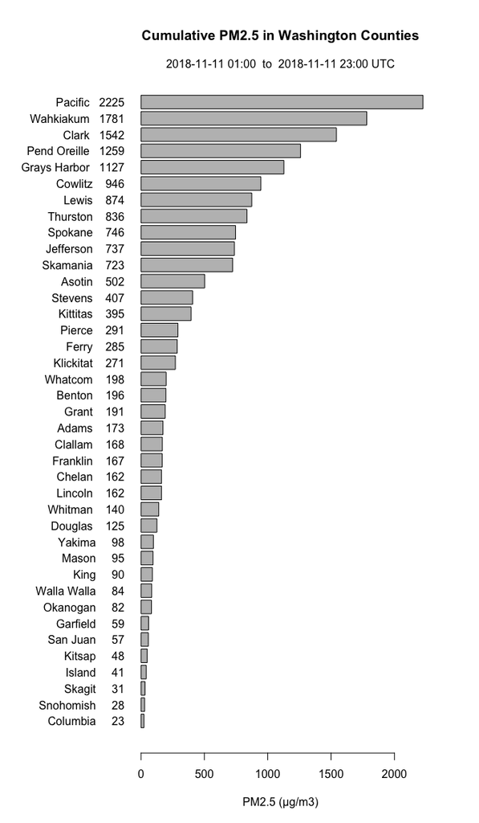

```r
# Remember to drop the initial 'datetime' column
countySums <-
  colSums(timeByCountyDF[,-1])

# NOTE:  Perhaps we should normalize by area?
# NOTE:  The `areaLand` column in the SPDF is in units of m^2
# NOTE:  If we do this we have to change the breaks when plotting maps.
###countySums <- countySums / (WA_counties$area/1e6)

# Extra margin on the left
par(mar = c(5,10,5,4) + .1)

# Sorted version for the barplot
sortedCountySums <- sort(countySums)

barplot(
  sortedCountySums,
  names = sprintf("%s  %5d", names(sortedCountySums), round(sortedCountySums)),
  horiz = TRUE,
  xlab = "PM2.5 (\u00b5g/m3)",
  las = 1 # horizontal names
)

subtitle <- sprintf(
  "%s  to  %s UTC",
  strftime(range(layerTimes)[1], "%Y-%m-%m %H:00", tz = "UTC"),
  strftime(range(layerTimes)[2], "%Y-%m-%m %H:00", tz = "UTC")
)

title("Cumulative PM2.5 in Washington Counties")
mtext(subtitle, line = 0)
```

```r
# Restore margins
par(mar = c(5,4,4,2) + .1)
```

### sp::map

We can create a highly customized map using the *sp* package plotting functions.

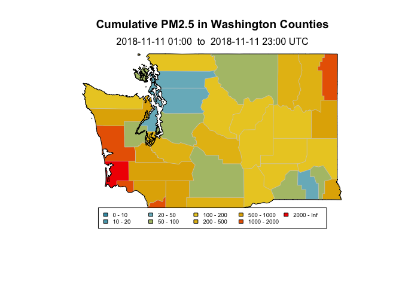

```r
# Use a fun palette with 9 levels (10 breaks)
library(wesanderson)
paletteFUN <- wes_palette("Zissou1", 9, type = "continuous")
breaks <- c(0, 10, 20, 50, 100, 200, 500, 1000, 2000, Inf)

# Use the same intervals to generate a new vector colors
binCode <- .bincode(countySums, breaks)
col_county <- paletteFUN[binCode]

# Change NA to "#bbbbbb" so that we get gray instead of white for NA counties
col_county[is.na(col_county)] <- "#CCCCCC"

# Chloropleth map
plot(WA_counties, col = col_county, border = "gray80", lwd = 0.5)
plot(WA, add = TRUE)

legend(
  "bottom",
  cex = 0.6,
  legend = paste0(round(breaks[1:9])," - ", round(breaks[2:10])),
  fill = paletteFUN,
  ncol = 5,
  xpd = NA,
  yjust = 0
)

title("Cumulative PM2.5 in Washington Counties")
mtext(subtitle, line = 0)
```

## Examples using *sf*, *dplyr* and *ggplot*

The following exmaples demonstrate higher level data handling and plotting for those comfortable with *dplyr* and *ggplot*.

When working with spatial data and ggplot/tidyverse, it is adventageous to use the [`sf`](https://r-spatial.github.io/sf/) package in place of the `sp` package mentioned above.

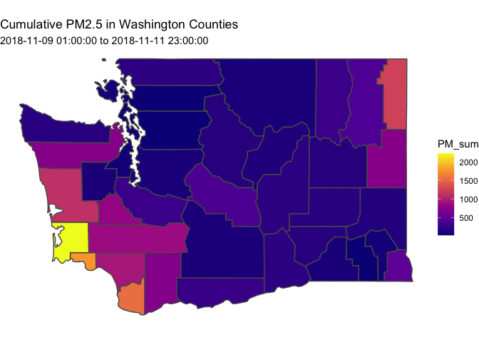

```r
# Import libraries
library(ggplot2)
library(dplyr)
library(sf)

# Create A backup of the original improved county data - for safety
WA_counties_improved_alt <-  WA_counties_improved

# Use dplyr mutate to a add a row summed column to the county spatial data.
# NOTE: Each column of the data represents a different hour, and each row a county.
#       Therefore a summation a cumulative rowwise sum of yields the total county PM2.5 count.
WA_counties_improved_alt@data <-
  WA_counties_improved_alt@data %>%
  mutate(PM_sum = rowSums(.[,10:ncol(.)]))

# Use the sf package to convert the sp/st data to sf
sf_WA_counties_improved <- st_as_sf(WA_counties_improved_alt)

# Plot using ggplot syntax
WA_counties_map <- ggplot(sf_WA_counties_improved) +
  geom_sf(aes(fill = PM_sum)) +
  scale_fill_viridis_c(option = "C") +
  theme_void() +
  labs(
    title = "Cumulative PM2.5 in Washington Counties",
    subtitle = paste0(range(layerTimes), collapse = ' to ') # use layer times
    )
print(WA_counties_map)
```

## Interactive Example using *plotly*

```r
library(plotly)

# add hover text HTML field
sf_WA_counties_improved$hover <-
  with(sf_WA_counties_improved, paste(name, '<br>', "Cumulative PM2.5: ", PM_sum))

# Create the interactive map
interactive_map <- plot_ly(
  sf_WA_counties_improved,
  split = ~name,
  hoveron = 'fills',
  text = ~hover,
  color = ~PM_sum,
  showlegend = FALSE
) %>%
  layout(
    title = list(
      text = paste0('Cumulative PM2.5 in Washington Counties',
                    '<br>',
                    '<sup>',
                    paste0(range(layerTimes), collapse = ' to '),
                    '</sup>')
    )
  ) %>%
  config(displayModeBar = FALSE)
# Show the map
interactive_map
```

[interactive chart not shown]

*Mazama Science*